# Exploratory Data Analysis - praca domowa 8

Wiktor Jakubowski

2022-01-31

# Wstęp

Raport obejmuje wstępną eksplorację danych ze zbioru [Red wine quality](https://www.kaggle.com/uciml/red-wine-quality-cortez-et-al-2009). Zbiór dotyczy właściwości fizyko-chemicznych win czerwonych, a także zawiera opinię dotyczącą jakości tego wina.

# Opis

W zbiorze danych mamy następujące kolumny:

- fixed.acidity - ilość kwasów zawartych w winie stale lub nieulatniających się, w mg/L
- volatile.acidity - ilość kwasu octowego w winie. Przy zbyt wysokim poziomie tego kwasu wino może nabrać nieprzyjemnego, octowego smaku, w g/L
- citric.acid - ilość kwasu cytrynowego w winie. Składnik dodatkowy - może dodać winom „świeżości” i smaku, w g/L
- residual.sugar - ilość cukru pozostała po zakończeniu fermentacji, w g/L
- chlorides - ilość soli w winie, w g/L
- free.sulfur.dioxide - ilość SO2 w formie wolnej, w ppm, zapobiega rozwojowi drobnoustrojów i utlenianiu wina
- total.sulfur.dioxide - łączna ilość SO2 w formie wolnej, w ppm
- density - gęstość wina w g/ml, jest zbliżona do gęstości wody. Zależy od procentowej zawartości alkoholu i cukru
- pH - skala pH opisująca kwasowo-zasadowość wina w skali od 0 (bardzo kwaśne) do 14 (bardzo zasadowe).
- sulphates - ilość siarczanów, które mogą przyczynić się do zwiększenia poziomu dwutlenku siarki (S02)
- alcohol - procent zawartości alkoholu w winie
- quality - zmienna wyjściowa określająca jakość wina. Wyliczana na podstawie danych sensorycznych, przyjmuje wartości od 0 (najsłabsze wino) do 10 (najlepsze).

# Dane ogólne

Badany zbiór danych ma następującą liczbę wierszy i kolumn: 1599, 12. Oznacza to, że w 1599 wierszach i 12 kolumnach mamy 19188 rekordów.

Sprawdźmy, jak wyglądają statystyki zmiennych:

| Zmienna | Liczba NA | Srednia | Odchylenie standardowe | Minimum | Maksimum | Unikalne wartosci |
| --- | --- | --- | --- | --- | --- | --- |
| fixed.acidity | 0 | 8.3196373 | 1.7410963 | 4.60000 | 15.90000 | 96 |
| volatile.acidity | 0 | 0.5278205 | 0.1790597 | 0.12000 | 1.58000 | 143 |
| citric.acid | 0 | 0.2709756 | 0.1948011 | 0.00000 | 1.00000 | 80 |
| residual.sugar | 0 | 2.5388055 | 1.4099281 | 0.90000 | 15.50000 | 91 |
| chlorides | 0 | 0.0874665 | 0.0470653 | 0.01200 | 0.61100 | 153 |
| free.sulfur.dioxide | 0 | 15.8749218 | 10.4601570 | 1.00000 | 72.00000 | 60 |
| total.sulfur.dioxide | 0 | 46.4677924 | 32.8953245 | 6.00000 | 289.00000 | 144 |
| density | 0 | 0.9967467 | 0.0018873 | 0.99007 | 1.00369 | 436 |
| pH | 0 | 3.3111132 | 0.1543865 | 2.74000 | 4.01000 | 89 |
| sulphates | 0 | 0.6581488 | 0.1695070 | 0.33000 | 2.00000 | 96 |
| alcohol | 0 | 10.4229831 | 1.0656676 | 8.40000 | 14.90000 | 65 |
| quality | 0 | 5.6360225 | 0.8075694 | 3.00000 | 8.00000 | 6 |

Wszystkie zmienne są ilościowe. Ponadto, nie ma żadnych braków danych, co czyni ten zbiór bardzo dogodnym w operowaniu.

## Zależności zmiennych

Zbadajmy jak poszczególne wartości korelują ze sobą nawzajem.

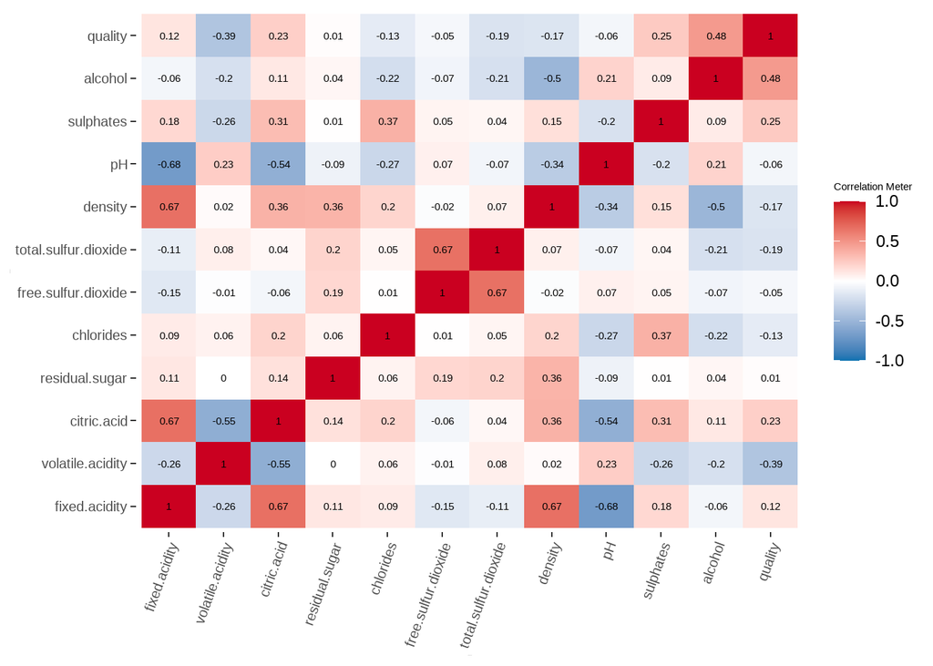

Możemy zaobserwować wyróżniające się korelacje pomiędzy zmiennymi:

1. gęstością a ilością kwasów nieutlaniających się (0.67, wysoki dodatni współczynnik korelacji)
2. ilością kwasu cytrynowego a ilością kwasów nieutleniających się (0.67, wysoki dodatni współczynnik korelacji)
3. pH a ilością kwasów nieutleniających się (-0.68, wysoki ujemny współczynnik korelacji)
4. zawartością alkoholu w winie a jego jakością (0.48, wysoki dodatni współczynnik korelacji)
5. ilością kwasu octowego w winie, a jego jakością (-0.39, znaczny ujemny współczynnik korelacji)

Korelację pomiędzy ilością kwasu cytrynowego a ilością kwasów nieutleniających się można łatwo sobie wytłumaczyć - kwas cytrynowy jest jednym z kwasów nieutleniających się, w związku z tym jasnym jest zależność między jego poziomem a poziomem wszystkich tego typu kwasów. Podobnie można dość natychmiastowo wytłumaczyć zależność między skalą pH wina a zawartością kwasów, jako że z definicji skala pH ma badać odczyn kwasowy środowiska. Najciekawsze są korelacje dotyczące wynikowej oceny jakości wina i innych zmiennych. Przyjrzyjmy się im bliżej.

# Rozkłady

Zobaczmy najpierw rozkłady trzech zmiennych, między którymi badamy korelację:

## Quality

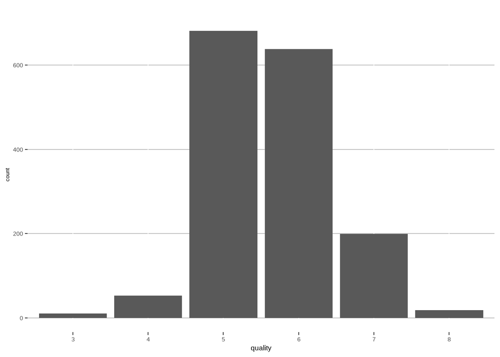

Można zaobserwować rozkład zbliżony do rozkładu normalnego - wszystkie wartości mieszczą się w przedziale 3 - 8, a ponad połowa z nich to wartość 5 lub 6.

## Alcohol

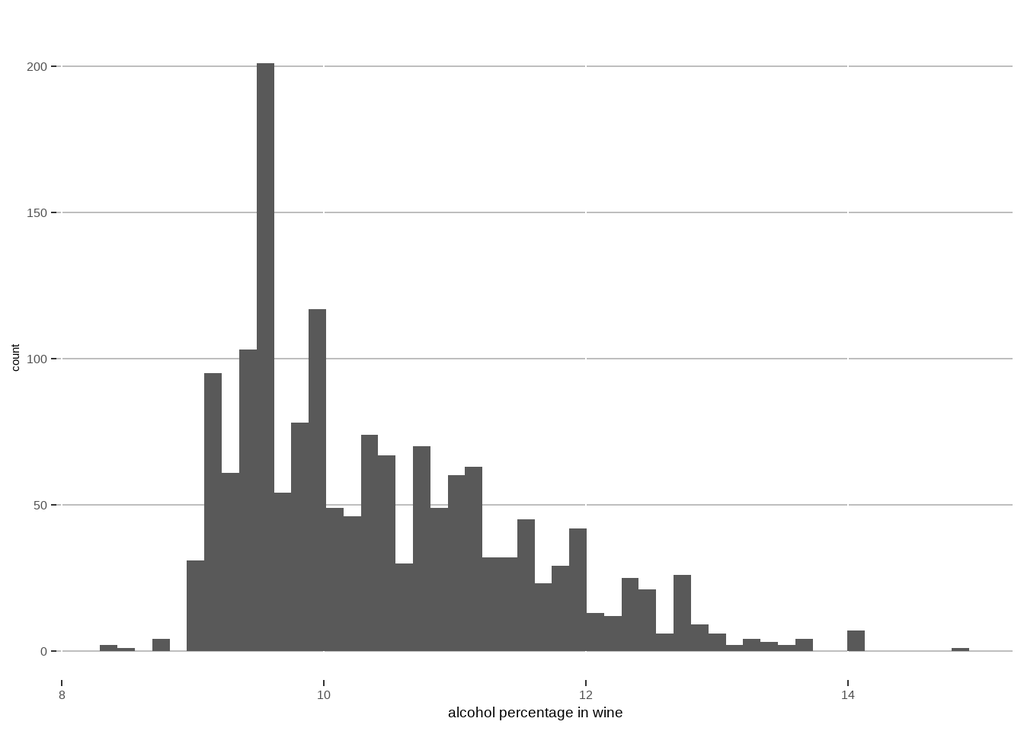

## Volatile Acidity

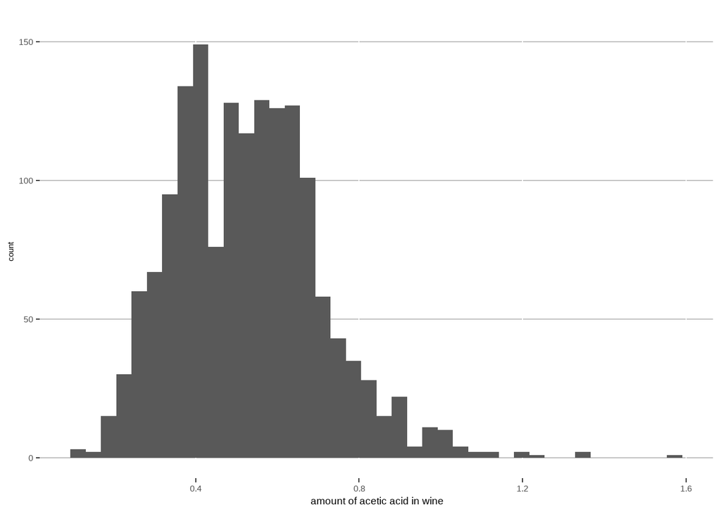

Możemy zaobserwować skupienie większości rekordów w przedziale 0.3 - 0.8 g / L, co jest dobrą oznaką. Według danych, poprawne stężenie kwasu octowego w czerownym winie powinno być nie większe niż 1.2 g / L. Możemy zaobserwować parę rekordów, dla których ta wartość jest większa, co by oznaczało, że będą to wina o słabej jakości lub po prostu wartości “oultier”.

# Zależności

Po zbadaniu rozkładów, przyjrzyjmy się faktycznym zaleznościom pomiędzy ilością alkoholu lub zawartością kwasu octowego, a wygenerowanej wartości określającej jej jakość. Z mapy ciepła wynika, że istnieje silna korelacja pomiędzy ilością alkoholu a jakością serwowanego wina. Sprawdźmy:

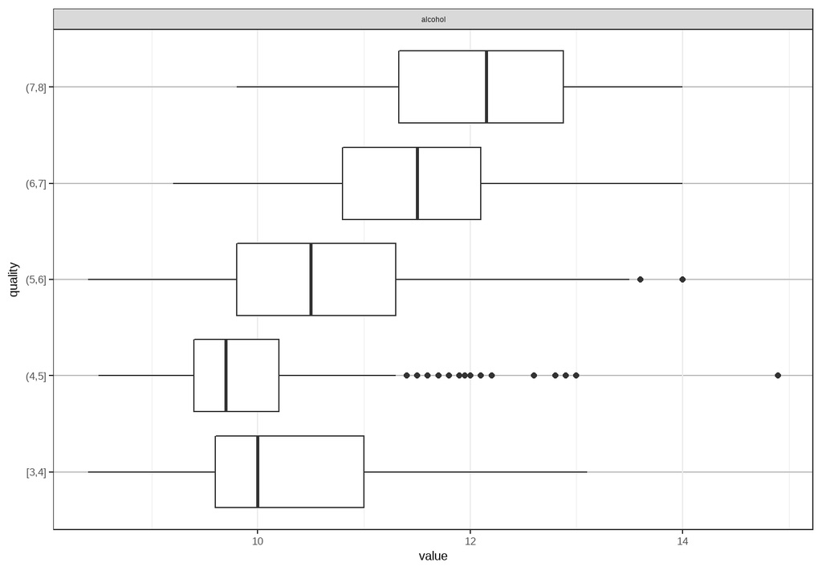

Widzimy ciekawe zjawisko. Mianowicie, wina o wyższej jakości mają tendencję do posiadania większej ilości alkoholu - około 11.5 - 12.5%. Wina niższej jakości cechują się z kolei niższym poziomem alkoholu.

Teraz przyjrzyjmy się korelacji ilości kwasu octowego i wyliczonej sensorycznie jakości wina:

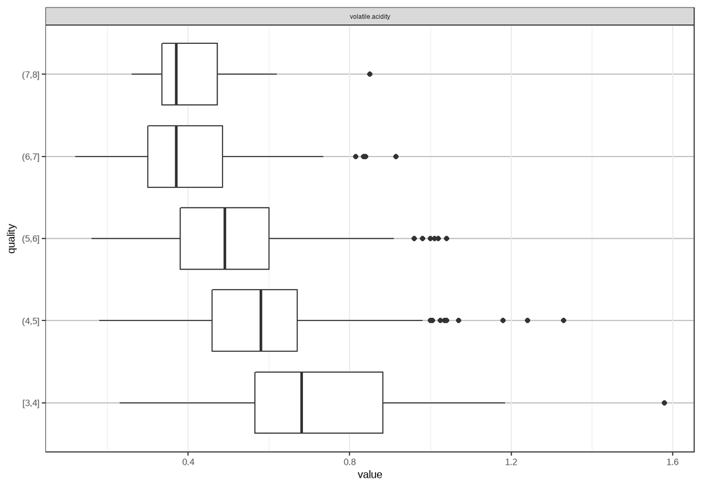

Ponownie, możemy zaobserwować wyraźną zależność pomiędzy dwoma zmiennymi. Okazuje się, że bardziej cenione wina mają około 0.3 - 0.5 g /L kwasu octowego, co pokrywa się też z wiedzą ekspercką. Gorszej jakości wina mają medianę zawartości tego kwasu na poziomie 0.6-0.7 g/L.

# Podsumowanie

- `alcohol`, czyli zawartość alkoholu w winie. Po wstępnej analizie wyraźnie widać zależność proporcjonalną między tymi dwiema wartościami, to znaczy statystycznie dobre wina mają więcej procentowo alkoholu.
- `volatile_acidity`, czyli zawartość kwasu octowego w winie. Eksploracja pokazała zależność odwrotnie proporcjonalną pomiędzy tą daną a wynikową oceną jakości - im mniej kwasu octowego, tym jakość wina wzrasta.

Oba te wnioski pokrywają się z powszechną intuicją dziedzinową - w kontekście alkoholu zwykle dobrym pomysłem jest zwiększenie jego ilości w winie (chociaż też bez przesady). Z drugiej strony, każdy z nas pewnie nie chciałby mieć do czynienia z winem o zbyt wysokiej kwasowości.